# Analysis of resale HDB flats prices

Hwee Yew Rong Kelvin

16 December 2019

## Objective of analysis

We want to analyse factors that may affect the selling price of HDB resale flats. Such factors include locational characteristics and structural characteristics. Irrelevant factors are excluded from the analysis.

## Load in the required libraries

```r
###   Ensure that the packages are already installed on your machine
library("dplyr")
```

```r
library("ggplot2")
library("httr")
library("stringr")
require("httr")
```

## Read in the CSV files

We read files in different batches, and they are to be stored directly in the working directory, and not in any folder.

```r
df_resale1 <- read.csv("~/resale-flat-prices-based-on-approval-date-1990-1999.csv", stringsAsFactors = FALSE)
df_resale2 <- read.csv("~/resale-flat-prices-based-on-approval-date-2000-feb-2012.csv", stringsAsFactors = FALSE)
df_resale3 <- read.csv("~/resale-flat-prices-based-on-registration-date-from-mar-2012-to-dec-2014.csv", stringsAsFactors = FALSE)
df_resale4 <- read.csv("~/resale-flat-prices-based-on-registration-date-from-jan-2015-to-dec-2016.csv", stringsAsFactors = FALSE)
df_resale5 <- read.csv("~/resale-flat-prices-based-on-registration-date-from-jan-2017-onwards.csv", stringsAsFactors = FALSE)
```

## Basic data clean-up

There is extra column in “df_resale4” and “df_resale5”, we drop the additional “remaining_lease” column since this info is not available in the earlier files

```r
df_resale4 <- select(df_resale4, -c("remaining_lease"))
df_resale5 <- select(df_resale5, -c("remaining_lease"))

###   combine the dataframes into one dataframe
df_resale <- rbind(df_resale1, df_resale2, df_resale3, df_resale4, df_resale5)
```

We further drop columns that are not critical for our investigation into the relationship between price against factors like location and structural characteristics (e.g. size)

```r
df_resale <- select(df_resale, -c("lease_commence_date"))
```

Engineer a new “year” column for EDA purposes

```r
df_resale$year <- str_sub(df_resale$month, 1, 4)
dim(df_resale)
```

```
## [1] 806568     10
```

Take a look at an extract of the combined dataframe

```r
head(df_resale); tail(df_resale)
```

```
##     month       town flat_type block      street_name storey_range
## 1 1990-01 ANG MO KIO    1 ROOM   309 ANG MO KIO AVE 1     10 TO 12
## 2 1990-01 ANG MO KIO    1 ROOM   309 ANG MO KIO AVE 1     04 TO 06
## 3 1990-01 ANG MO KIO    1 ROOM   309 ANG MO KIO AVE 1     10 TO 12
## 4 1990-01 ANG MO KIO    1 ROOM   309 ANG MO KIO AVE 1     07 TO 09
## 5 1990-01 ANG MO KIO    3 ROOM   216 ANG MO KIO AVE 1     04 TO 06
## 6 1990-01 ANG MO KIO    3 ROOM   211 ANG MO KIO AVE 3     01 TO 03
##   floor_area_sqm     flat_model resale_price year
## 1             31       IMPROVED         9000 1990
## 2             31       IMPROVED         6000 1990
## 3             31       IMPROVED         8000 1990
## 4             31       IMPROVED         6000 1990
## 5             73 NEW GENERATION        47200 1990
## 6             67 NEW GENERATION        46000 1990
```

```
##          month   town flat_type block    street_name storey_range
## 806563 2019-10 YISHUN EXECUTIVE   791   YISHUN AVE 2     04 TO 06
## 806564 2019-10 YISHUN EXECUTIVE   406   YISHUN AVE 6     01 TO 03
## 806565 2019-10 YISHUN EXECUTIVE   324    YISHUN CTRL     04 TO 06
## 806566 2019-10 YISHUN EXECUTIVE   326 YISHUN RING RD     01 TO 03
## 806567 2019-10 YISHUN EXECUTIVE   606   YISHUN ST 61     10 TO 12
## 806568 2019-10 YISHUN EXECUTIVE   824   YISHUN ST 81     04 TO 06
##        floor_area_sqm flat_model resale_price year
## 806563            146 Maisonette       550000 2019
## 806564            148 Maisonette       566000 2019
## 806565            142  Apartment       510000 2019
## 806566            146 Maisonette       530000 2019
## 806567            146 Maisonette       638000 2019
## 806568            146 Maisonette       628000 2019
```

There are repeated info, e.g. rows 1 to 4 are all the same except for “storey_range” and “resale_price”. So, we consider calculating an average resale_price, then thereafter, collapse these columns, else too many columns. Also note that we are looking at just 2019’s numbers (afterall, some flats may no longer exist). The last “mutate” creates a column that combines blk number and street name

```r
df <- df_resale %>%
        group_by(year, town, flat_type, block, street_name, floor_area_sqm, flat_model) %>%
            summarise(avg_resale_price = mean(resale_price)) %>%
                filter(year == "2019") %>%
                    mutate(blk_street_name = str_replace_all(paste(block, street_name), " ", "%20"))

head(df)
```

```
## # A tibble: 6 x 9
## # Groups:   year, town, flat_type, block, street_name, floor_area_sqm [6]
##   year  town      flat_type block street_name    floor_area_sqm flat_model
##   <chr> <chr>     <chr>     <chr> <chr>                   <dbl> <chr>
## 1 2019  ANG MO K~ 2 ROOM    116   ANG MO KIO AV~             44 Improved
## 2 2019  ANG MO K~ 2 ROOM    170   ANG MO KIO AV~             45 Improved
## 3 2019  ANG MO K~ 2 ROOM    172   ANG MO KIO AV~             45 Improved
## 4 2019  ANG MO K~ 2 ROOM    174   ANG MO KIO AV~             45 Improved
## 5 2019  ANG MO K~ 2 ROOM    314   ANG MO KIO AV~             44 Improved
## 6 2019  ANG MO K~ 2 ROOM    323   ANG MO KIO AV~             44 Improved
## # ... with 2 more variables: avg_resale_price <dbl>, blk_street_name <chr>
```

```r
dim(df)
```

```
## [1] 10900     9
```

## Latitude and logitude information from OneMap.SG

We want to engineer latitude and longitude info into the dataframe, we need API access from Onemap.sg. We get the access token from onemap

```r
head_url <- "https://developers.onemap.sg"
post_url <- paste0(head_url, "/privateapi/auth/post/getToken")
body <- list('email' = 'hwee.yewrong.kelvin@gmail.com', 'password' = 'testing123') # for purpose of assignment, i used this approach
res <- POST(post_url, body = body, verbose())
```

```r
content(res)
```

```
## $access_token
## [1] "eyJ0eXAiOiJKV1QiLCJhbGciOiJIUzI1NiJ9.eyJzdWIiOjM3MDgsInVzZXJfaWQiOjM3MDgsImVtYWlsIjoiaHdlZS55ZXdy….JA57cLyAgqbEbkCv9kp-i0Sg6wHJ9mwfj1xEMNLmwOQ"
##
## $expiry_timestamp
## [1] "1576580502"
```

We create a function to perform a GET request

```r
get_request <- function(addr, index){

    head_url <- "https://developers.onemap.sg"
    get_url <- paste0(head_url, "/commonapi/search", "?searchVal=", addr, "&returnGeom=Y&getAddrDetails=N&pageNum=1")
    get_res <- GET(get_url, verbose())

    if(content(get_res)[1] > 0){    lat <- content(get_res)$'results'[[1]]$'LATITUDE'
                                    long <- content(get_res)$'results'[[1]]$'LONGITUDE'
                                    lat_long <- c(lat, long)
    } else{   lat <- 'not found'
              long <- 'not found'
              lat_long <- c(lat, long)}

    result <- ifelse(index == "lat", lat_long[1], lat_long[2])
    return(result)
}


df_selected <- df
```

The following codes were used to create columns called “latitude” and “longitude”. However, they are hashed out because they take a long time to run. We create a new CSV file titled “exported_resale_data.csv” that can be used for the later part of the analysis and to save computation time

```r
# for(i in c(1:length(df_selected$blk_street_name)))
#     df_selected$latitude[i] <- get_request(df_selected$blk_street_name[i], "lat")
#
# for(i in c(1:length(df_selected$blk_street_name)))
#     df_selected$longitude[i] <- get_request(df_selected$blk_street_name[i], "long")
#
# str(df_selected)
# head(df_selected)
#

# df_selected[df_selected$latitude == "not found",]  # we found some rows with missing lat long
# indexes <- df_selected[df_selected$latitude == "not found", 1] # we collect the corresponding index numbers
#
#
# # we also separately used Singpost's website to retrieve the postal code, and record them here in order
# code_list = c("320007", "320014", "328023", "321020",
#               "320003", "320005", "320006", "320008",
#               "320001", "320010", "320011", "320014",
#               "320020", "320023", "321004", "320005",
#               "320005", "320006", "320006", "320008",
#               "320009", "320013", "328023", "321021")
#
# df_selected <- read.csv("~/exported_resale_data.csv", stringsAsFactors = FALSE)
#
# for(i in c(1:length(indexes)))
#     df_selected$latitude[indexes[i]] <- get_request(code_list[i], "lat")
#
# for(i in c(1:length(indexes)))
#     df_selected$longitude[indexes[i]] <- get_request(code_list[i], "long")
#
#
# df_selected$latitude[indexes]
# df_selected$longitude[indexes]
#
# write.csv(df_selected, paste0(getwd(), "\\exported_resale_data.csv"))
```

## Exploratory data analysis

We start by reading in the cleaned up data that was created in the earlier step

```r
df_selected <- read.csv("~/exported_resale_data.csv", stringsAsFactors = FALSE)
df_selected$latitude <- as.numeric(df_selected$latitude)
df_selected$longitude <- as.numeric(df_selected$longitude)
head(df_selected)
```

```
##   X.1 X year       town flat_type block      street_name floor_area_sqm
## 1   1 1 2019 ANG MO KIO    2 ROOM   116 ANG MO KIO AVE 4             44
## 2   2 2 2019 ANG MO KIO    2 ROOM   170 ANG MO KIO AVE 4             45
## 3   3 3 2019 ANG MO KIO    2 ROOM   172 ANG MO KIO AVE 4             45
## 4   4 4 2019 ANG MO KIO    2 ROOM   174 ANG MO KIO AVE 4             45
## 5   5 5 2019 ANG MO KIO    2 ROOM   314 ANG MO KIO AVE 3             44
## 6   6 6 2019 ANG MO KIO    2 ROOM   323 ANG MO KIO AVE 3             44
##   flat_model avg_resale_price                blk_street_name latitude
## 1   Improved           187000 116%20ANG%20MO%20KIO%20AVE%204 1.373346
## 2   Improved           220000 170%20ANG%20MO%20KIO%20AVE%204 1.374001
## 3   Improved           187000 172%20ANG%20MO%20KIO%20AVE%204 1.374777
## 4   Improved           197500 174%20ANG%20MO%20KIO%20AVE%204 1.375097
## 5   Improved           186000 314%20ANG%20MO%20KIO%20AVE%203 1.366227
## 6   Improved           187500 323%20ANG%20MO%20KIO%20AVE%203 1.367542
##   longitude
## 1  103.8365
## 2  103.8364
## 3  103.8367
## 4  103.8376
## 5  103.8501
## 6  103.8478
```

```r
sapply(df_selected, function(x) sum(is.na(x))) # no null values
```

```
##              X.1                X             year             town
##                0                0                0                0
##        flat_type            block      street_name   floor_area_sqm
##                0                0                0                0
##       flat_model avg_resale_price  blk_street_name         latitude
##                0                0                0                0
##        longitude
##                0
```

Ranking of prices based on town (flat type as colour)

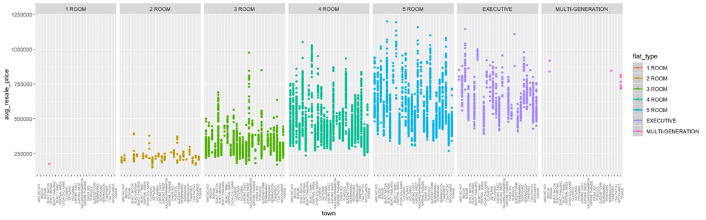

```r
qplot(town, avg_resale_price, data = df_selected,
      color = flat_type, facets = .~flat_type) +
      geom_smooth(method = "lm") +
      theme(axis.text.x = element_text(angle = 90)) +
      theme(axis.text.x = element_text(size = 5))
```

Ranking of prices based on town (floor area as colour)

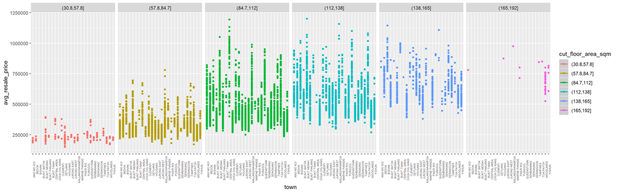

```r
df_selected$cut_floor_area_sqm <- cut(df_selected$floor_area_sqm, 6)
qplot(town, avg_resale_price, data = df_selected,
      color = cut_floor_area_sqm, facets = .~cut_floor_area_sqm) +
      geom_smooth(method = "lm") +
      theme(axis.text.x = element_text(angle = 90)) +
      theme(axis.text.x = element_text(size = 5))
```

Ranking of prices based on town (flat model as colour)

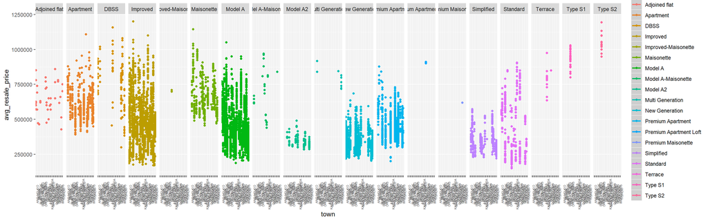

```r
qplot(town, avg_resale_price, data = df_selected,
      color = flat_model, facets = .~flat_model) +
      geom_smooth(method = "lm") +
      theme(axis.text.x = element_text(angle = 90)) +
      theme(axis.text.x = element_text(size = 5))
```

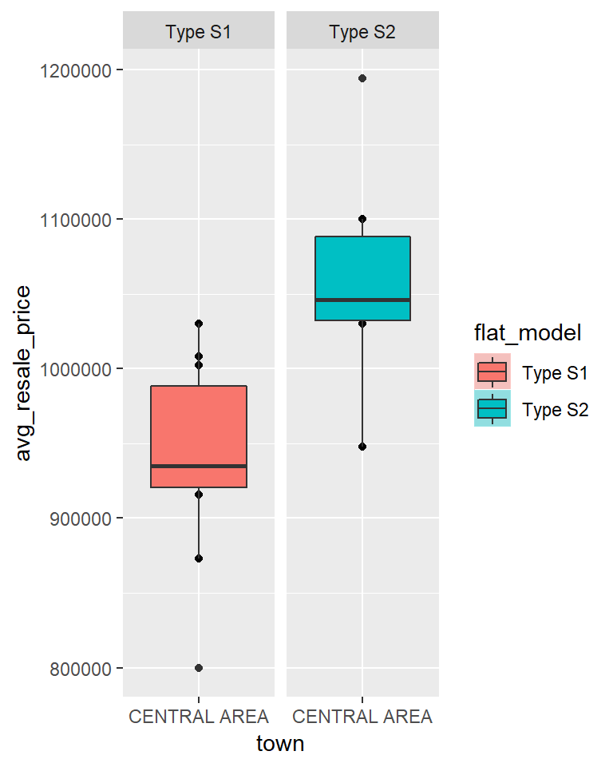

```r
qplot(town, avg_resale_price, data = df_selected[df_selected$flat_model == c("Type S1", "Type S2"),],
      fill = flat_model, facets = .~flat_model) +
      geom_smooth(method = "lm") + geom_boxplot()
```

We do a cut on the average prices and plot onto the map

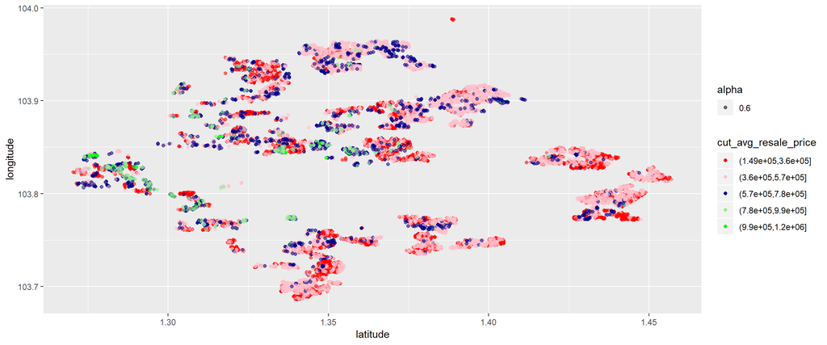

```r
df_selected$cut_avg_resale_price <- cut(df_selected$avg_resale_price, 5)
ggplot(data = df_selected, aes(x=latitude, y=longitude)) +
    geom_point(aes(alpha = 0.6, color = cut_avg_resale_price)) +
    scale_colour_manual(values=c("red", "pink", "dark blue", "light green", "green"))
```

We use the cut average prices and do a bar plot

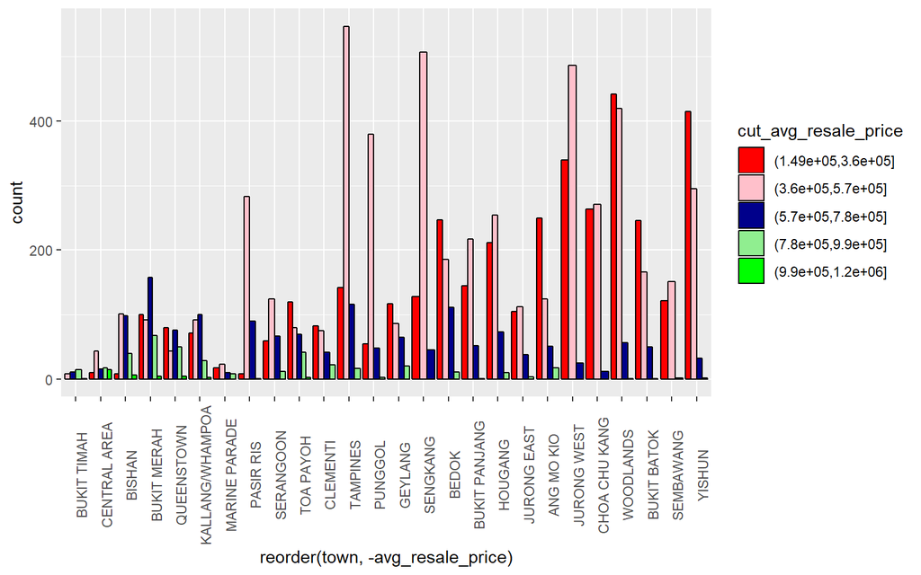

```r
ggplot(data = df_selected, aes(x=reorder(town, -avg_resale_price), fill = cut_avg_resale_price)) +
    geom_bar(position = "dodge", color = "black") +
    theme(axis.text.x = element_text(angle = 90)) +
    scale_fill_manual(values=c("red", "pink", "dark blue", "light green", "green"))
```